# chapter5

Kalle Karvonen

2023-12-04

# Chapter 5 Dimensionality reduction

- In this chapter we are working with the human dataset from https://raw.githubusercontent.com/KimmoVehkalahti/Helsinki-Open-Data-Science/master/datasets/human2.csv”
- This dataset consists of certain welfare parameters of countries ranked, these include Maternal mortality rate education rate and gender equality parameters.

“GNI” = Gross National Income per capita.

“Life.Exp” = Life expectancy at birth

“Edu.Exp” = Expected years of schooling

“Mat.Mor” = Maternal mortality ratio

“Ado.Birth” = Adolescent birth rate

“Parli.F” = Percetange of female representatives in parliament

“Edu2.FM” = Proportion of females with at least secondary education divided by males “Labo.FM” = Proportion of females in the labour force divided by males

```r
human <-read.csv("C:/Users/Kalka/OneDrive/Desktop/Random/School/Open_Data/IODS-project/data/human.csv")

# moving country names to rownames to a new dataframe human_
library(dplyr)
library(tibble)
human_ <- column_to_rownames(human, "Country")
summary(human_)
```

```
##     Edu2.FM          Labo.FM          Edu.Exp         Life.Exp
##  Min.   :0.1717   Min.   :0.1857   Min.   : 5.40   Min.   :49.00
##  1st Qu.:0.7264   1st Qu.:0.5984   1st Qu.:11.25   1st Qu.:66.30
##  Median :0.9375   Median :0.7535   Median :13.50   Median :74.20
##  Mean   :0.8529   Mean   :0.7074   Mean   :13.18   Mean   :71.65
##  3rd Qu.:0.9968   3rd Qu.:0.8535   3rd Qu.:15.20   3rd Qu.:77.25
##  Max.   :1.4967   Max.   :1.0380   Max.   :20.20   Max.   :83.50
##       GNI            Mat.Mor         Ado.Birth         Parli.F
##  Min.   :   581   Min.   :   1.0   Min.   :  0.60   Min.   : 0.00
##  1st Qu.:  4198   1st Qu.:  11.5   1st Qu.: 12.65   1st Qu.:12.40
##  Median : 12040   Median :  49.0   Median : 33.60   Median :19.30
##  Mean   : 17628   Mean   : 149.1   Mean   : 47.16   Mean   :20.91
##  3rd Qu.: 24512   3rd Qu.: 190.0   3rd Qu.: 71.95   3rd Qu.:27.95
##  Max.   :123124   Max.   :1100.0   Max.   :204.80   Max.   :57.50
```

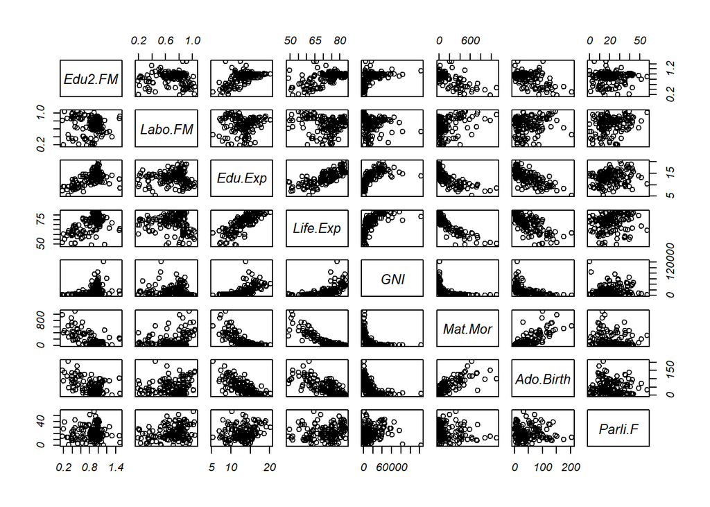

```r
pairs(human_)
```

- From these plots you can see some skewing in data especially with GNI and the variables such as Ado.Birth which would seem to indicate that Adolescent birth is more common in countries with low GNI.
- This data could use some PCA

#### PCA

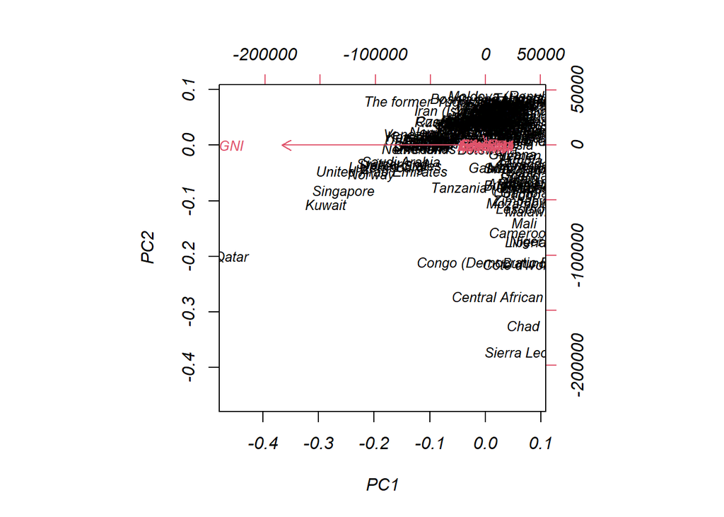

```r
# perform principal component analysis
pca_human <- prcomp(human_)

# draw a biplot of the principal component representation and the original variables
biplot(pca_human, choices = 1:2,cex=0.8)
```

- Based on this unscaled data it is pretty hard to see anything on a biplot and the plot would need to be tinkered with. Howere we can quite clearly see that a lot of variables plot around the same area. In this type of plots the arrows would be useful to determine certain properties of our data

- The angle between the arrows can be interpreted as the correlation between the variables.
- The angle between a variable and a PC axis can be interpreted as the correlation between the two
- The length of the arrows are proportional to the standard deviations of the variables.
- As you can see above the arrows aside from GNI are very hard to see and that would mean that there is a large standard deviation in GNI
- All of the arrows seem straight so this would not show any correlations

```r
# create and print out a summary of pca_human
s <- summary(pca_human)


# rounded percentanges of variance captured by each PC
pca_pr <- round(1*s$importance[2, ], digits = 5)
pca_pr
```

```
##    PC1    PC2    PC3    PC4    PC5    PC6    PC7    PC8
## 0.9999 0.0001 0.0000 0.0000 0.0000 0.0000 0.0000 0.0000
```

- based on the summary it seems that for this unscaled data the first principal component explains almost all of the variance.
- what if we standardize the variables

```r
#scaling the data
human_std <- scale(human_)
summary(human_std)
```

```
##     Edu2.FM           Labo.FM           Edu.Exp           Life.Exp
##  Min.   :-2.8189   Min.   :-2.6247   Min.   :-2.7378   Min.   :-2.7188
##  1st Qu.:-0.5233   1st Qu.:-0.5484   1st Qu.:-0.6782   1st Qu.:-0.6425
##  Median : 0.3503   Median : 0.2316   Median : 0.1140   Median : 0.3056
##  Mean   : 0.0000   Mean   : 0.0000   Mean   : 0.0000   Mean   : 0.0000
##  3rd Qu.: 0.5958   3rd Qu.: 0.7350   3rd Qu.: 0.7126   3rd Qu.: 0.6717
##  Max.   : 2.6646   Max.   : 1.6632   Max.   : 2.4730   Max.   : 1.4218
##       GNI             Mat.Mor          Ado.Birth          Parli.F
##  Min.   :-0.9193   Min.   :-0.6992   Min.   :-1.1325   Min.   :-1.8203
##  1st Qu.:-0.7243   1st Qu.:-0.6496   1st Qu.:-0.8394   1st Qu.:-0.7409
##  Median :-0.3013   Median :-0.4726   Median :-0.3298   Median :-0.1403
##  Mean   : 0.0000   Mean   : 0.0000   Mean   : 0.0000   Mean   : 0.0000
##  3rd Qu.: 0.3712   3rd Qu.: 0.1932   3rd Qu.: 0.6030   3rd Qu.: 0.6127
##  Max.   : 5.6890   Max.   : 4.4899   Max.   : 3.8344   Max.   : 3.1850
```

- basic scaling by using means. Now lets use the scaled data on the same analysis as before

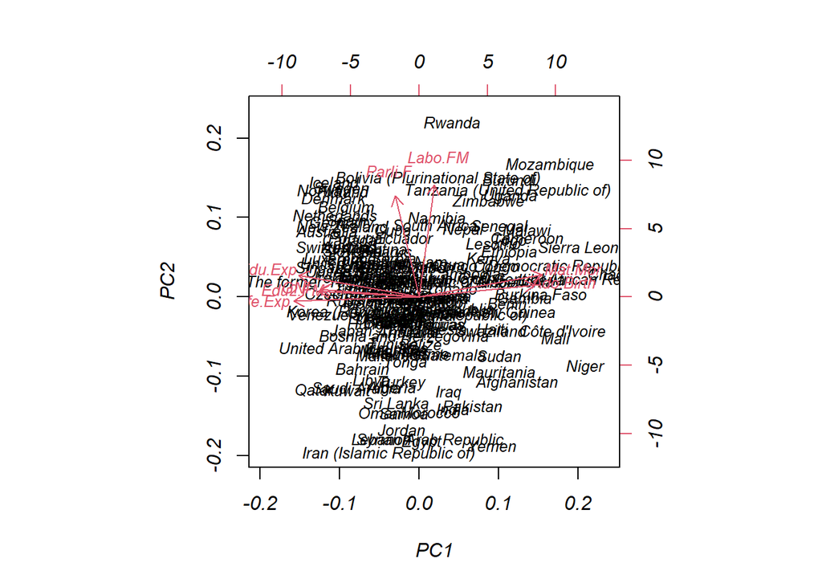

```r
# perform principal component analysis
pca_human_std <- prcomp(human_std)

# draw a biplot of the principal component representation and the original variables
biplot(pca_human_std, choices = 1:2,cex=0.8)
```

```r
# create and print out a summary of pca_human
s <- summary(pca_human_std)


# rounded percentanges of variance captured by each PC
pca_pr_std <- round(1*s$importance[2, ], digits = 5)
pca_pr_std
```

```
##     PC1     PC2     PC3     PC4     PC5     PC6     PC7     PC8
## 0.53605 0.16237 0.09571 0.07583 0.05477 0.03595 0.02634 0.01298
```

On the scaled data we can actually see that the first PC now only explains around 53% of variability and the next around 16%. For dimensionality reduction it seems valid to keep atleast the first two PC:s in this situation to represent the data in a low dimension space. I believe the scaled data would provide more intepretable data compared to the first raw data.

### Tea data

- now lets work with tea dataset from the FactoMineR package where individuals were asked about how they drink tea

```r
library(FactoMineR)
tea <- read.csv("https://raw.githubusercontent.com/KimmoVehkalahti/Helsinki-Open-Data-Science/master/datasets/tea.csv", stringsAsFactors = TRUE)
dim(tea)
```

```
## [1] 300  36
```

```r
str(tea)
```

```
## 'data.frame':    300 obs. of  36 variables:
##  $ breakfast       : Factor w/ 2 levels "breakfast","Not.breakfast": 1 1 2 2 1 2 1 2 1 1 ...
##  $ tea.time        : Factor w/ 2 levels "Not.tea time",..: 1 1 2 1 1 1 2 2 2 1 ...
##  $ evening         : Factor w/ 2 levels "evening","Not.evening": 2 2 1 2 1 2 2 1 2 1 ...
##  $ lunch           : Factor w/ 2 levels "lunch","Not.lunch": 2 2 2 2 2 2 2 2 2 2 ...
##  $ dinner          : Factor w/ 2 levels "dinner","Not.dinner": 2 2 1 1 2 1 2 2 2 2 ...
##  $ always          : Factor w/ 2 levels "always","Not.always": 2 2 2 2 1 2 2 2 2 2 ...
##  $ home            : Factor w/ 2 levels "home","Not.home": 1 1 1 1 1 1 1 1 1 1 ...
##  $ work            : Factor w/ 2 levels "Not.work","work": 1 1 2 1 1 1 1 1 1 1 ...
##  $ tearoom         : Factor w/ 2 levels "Not.tearoom",..: 1 1 1 1 1 1 1 1 1 2 ...
##  $ friends         : Factor w/ 2 levels "friends","Not.friends": 2 2 1 2 2 2 1 2 2 2 ...
##  $ resto           : Factor w/ 2 levels "Not.resto","resto": 1 1 2 1 1 1 1 1 1 1 ...
##  $ pub             : Factor w/ 2 levels "Not.pub","pub": 1 1 1 1 1 1 1 1 1 1 ...
##  $ Tea             : Factor w/ 3 levels "black","Earl Grey",..: 1 1 2 2 2 2 2 1 2 1 ...
##  $ How             : Factor w/ 4 levels "alone","lemon",..: 1 3 1 1 1 1 1 3 3 1 ...
```

[output cut: 22 more lines]

```r
view(tea)
```

- Lets choose some columns to test with MCA, for example in this I’d like to test the following (frequency,SPC,Age_Q,how ) to see if perhaps we can see anythign when looking at how much tea the individuals drank what is their social standing and age and how they made their tea

```r
# select the 'keep_columns' to create a new dataset
tea_test <- select(tea, c("age_Q", "frequency", "how", "SPC"))
```

- Lets perform a MCA on the data

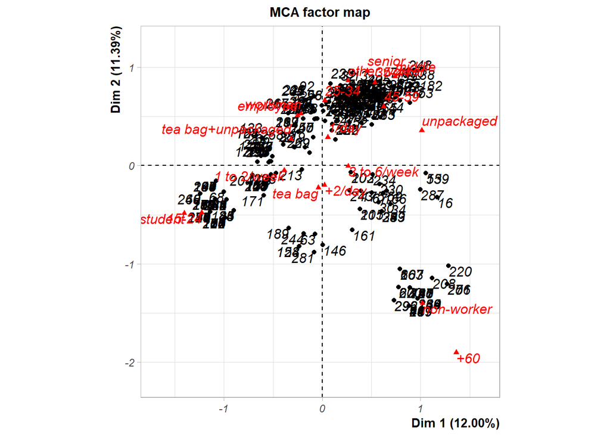

```r
mca <- MCA(tea_test, graph = FALSE)
plot.MCA(mca)
```

- This data is also a bit messy to look at due to all the observations. When looking at a MCA plot we would like to look at a multitude of different things. For example we see some clustering around certain categories which makes sence since the closer an observation is to a category means that it better represents the observation. In this case these clusters seem to happen around the social status of the people. - Another observation that could be made is that the way of drinking tea from a tea bag ( typically a fast and convenient method) seems to be close to the higher tea consumption/week categories. Though it is important to keep in mind that the distance to orgigin is also a factor and categories close to origin might not be well represented by MCA

```r
p <- summary(mca)
```

```
##
## Call:
## MCA(X = tea_test, graph = FALSE)
##
##
## Eigenvalues
##                        Dim.1   Dim.2   Dim.3   Dim.4   Dim.5   Dim.6   Dim.7
## Variance               0.450   0.427   0.318   0.307   0.283   0.279   0.269
## % of var.             12.004  11.387   8.473   8.174   7.559   7.446   7.161
## Cumulative % of var.  12.004  23.392  31.864  40.039  47.598  55.044  62.205
##                        Dim.8   Dim.9  Dim.10  Dim.11  Dim.12  Dim.13  Dim.14
## Variance               0.255   0.236   0.221   0.207   0.172   0.168   0.087
## % of var.              6.788   6.298   5.907   5.514   4.593   4.484   2.317
## Cumulative % of var.  68.992  75.290  81.197  86.711  91.304  95.788  98.105
##                       Dim.15
## Variance               0.071
## % of var.              1.895
## Cumulative % of var. 100.000
##
## Individuals (the 10 first)
##                Dim.1    ctr   cos2    Dim.2    ctr   cos2    Dim.3    ctr
## 1           |  0.480  0.171  0.058 |  0.694  0.376  0.121 |  0.365  0.139
## 2           |  0.514  0.196  0.079 |  0.600  0.281  0.108 |  0.126  0.017
## 3           |  0.324  0.078  0.021 |  0.400  0.125  0.032 |  0.625  0.410
## 4           | -0.976  0.705  0.450 | -0.343  0.092  0.056 |  0.352  0.130
## 5           |  0.132  0.013  0.007 |  0.263  0.054  0.027 | -0.089  0.008
## 6           | -0.976  0.705  0.450 | -0.343  0.092  0.056 |  0.352  0.130
## 7           |  0.453  0.152  0.036 |  0.604  0.285  0.064 | -0.343  0.123
## 8           |  0.316  0.074  0.020 |  0.566  0.250  0.065 |  0.103  0.011
## 9           |  0.260  0.050  0.015 |  0.720  0.405  0.118 | -0.567  0.338
## 10          |  0.260  0.050  0.015 |  0.720  0.405  0.118 | -0.567  0.338
##               cos2
## 1            0.033 |
## 2            0.005 |
## 3            0.078 |
## 4            0.058 |
## 5            0.003 |
## 6            0.058 |
## 7            0.021 |
## 8            0.002 |
```

[output cut: 18 more lines]

```
## 25-34       |   0.359   2.336   0.039   3.396 |
## 35-44       |   0.173   0.315   0.005   1.176 |
## 45-59       |  -0.365   2.135   0.034  -3.191 |
## +2/day      |  -0.459   7.024   0.155  -6.803 |
## 1 to 2/week |   0.246   0.696   0.010   1.760 |
## 1/day       |   0.835  17.385   0.323   9.833 |
## 3 to 6/week |  -0.936   7.820   0.112  -5.789 |
## tea bag     |   0.490  10.699   0.314   9.686 |
##
## Categorical variables (eta2)
##               Dim.1 Dim.2 Dim.3
## age_Q       | 0.816 0.798 0.072 |
## frequency   | 0.031 0.043 0.418 |
## how         | 0.155 0.067 0.338 |
## SPC         | 0.798 0.801 0.442 |
```

- Looking at the eigenvalues of MCA we see that there are no good dimensions for this MCA to explain variances with the highest being dim 1 with 12%.
- So these columns that I chose quickly seem to not be suitable together for an MCA analysis.